# Ex16 COL

PIE2

Tardor 2019-2010

### En un estudi per estudiar el nivell de colesterol en sang, en persones en edat de creixement (9-20 anys), s’ha plantejat un model per explicar el nivell de colesterol *(C)* en funció del pes *(P)*, edat *(E)* i alçada *(H)*.

### **“És conegut que el Pes és un dels factors que influeixen en l’augment del nivell de Colesterol”**

### Les dades experimentals són independents i estan en el fitxer “col.csv”.

```r
#setwd("..")
library(car)
```

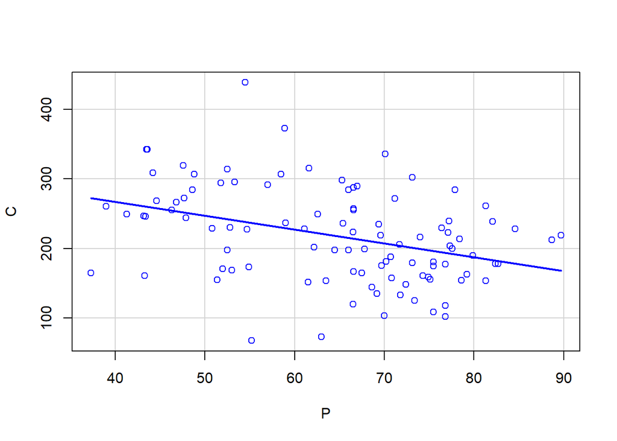

```r
dd <- read.csv2("../data/col.csv")
n<-dim(dd)[1]

# a-0) DESCRIPTIVA
sp(C~P,boxplot=F,smooth=F,dd)
```

```r
# Model Nul
mod0<-lm(C~1,dd)
```

**a)** Per començar plategeu la recta de regressió del colesterol respecte el pes.

```r
mod<-lm(C~P,dd)
```

**i.** Trobeu els coeficients de la recta de regressió i la variància del error.

```r
summary(mod)
```

```
##
## Call:
## lm(formula = C ~ P, data = dd)
##
## Residuals:
##     Min      1Q  Median      3Q     Max
## -169.24  -39.81   -4.49   47.19  200.37
##
## Coefficients:
##             Estimate Std. Error t value Pr(>|t|)
## (Intercept) 346.2251    33.1983   10.43  < 2e-16 ***
## P            -1.9835     0.5046   -3.93 0.000158 ***
## ---
## Signif. codes:  0 '***' 0.001 '**' 0.01 '*' 0.05 '.' 0.1 ' ' 1
##
## Residual standard error: 63.55 on 98 degrees of freedom
## Multiple R-squared:  0.1362, Adjusted R-squared:  0.1274
## F-statistic: 15.45 on 1 and 98 DF,  p-value: 0.0001581
```

**ii.** Dieu si el pes explica el nivell de colesterol. Veieu alguna contradicció en els resultats?

**iii.** Dibuixeu, junt amb les dades la banda 99% de confiança i la de predicció del colesterol.

```r
# a- Banda de confiança i de predicció
CC<-predict(mod,interval="confidence",alpha=0.01)
CP<-predict(mod,interval="prediction",alpha=0.01)
```

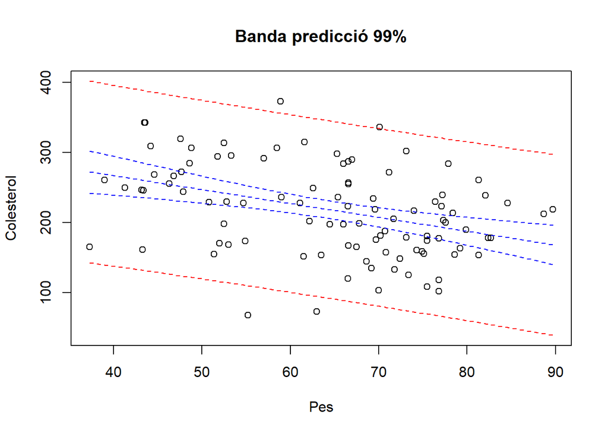

```r
O<-order(dd$P)
plot(dd$P,dd$C,ylim=c(min(CP),max(CP)),xlab="Pes",ylab="Colesterol",main="Banda predicció 99%")
lines(dd$P[O],CC[O,"fit"],lty=2,col="blue")
lines(dd$P[O],CC[O,"lwr"],lty=2,col="blue")
lines(dd$P[O],CC[O,"upr"],lty=2,col="blue")
lines(dd$P[O],CP[O,"lwr"],lty=2,col="red")
lines(dd$P[O],CP[O,"upr"],lty=2,col="red")
```

**iv.** Utilitzant diagnòstics dieu si el model és correcte.

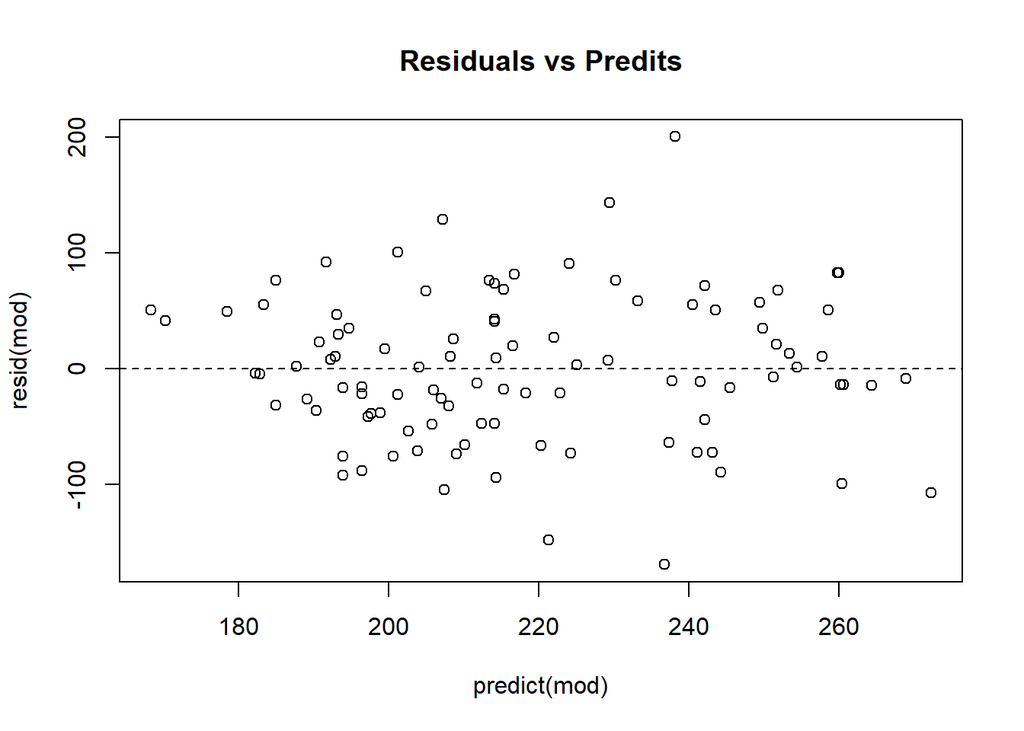

```r
# a-Diagnòstic: TENDÈNCIES

plot(predict(mod),resid(mod),main="Residuals vs Predits")
abline(h=0,lty=2)
```

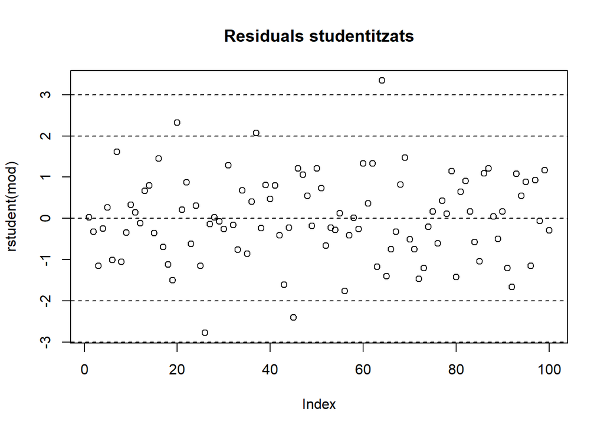

```r
# a-Diagnòstic: VALORS ESTRANYS
plot(rstudent(mod),main="Residuals studentitzats")
abline(h=c(-3,-2,0,2,3),lty=2)
```

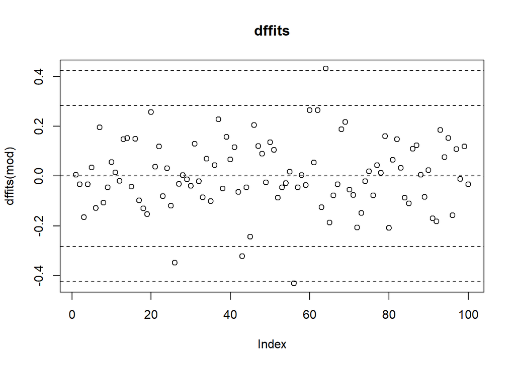

```r
# a-Diagnòstic: VALORS INFLUENTS
p<-2
plot(dffits(mod),main="dffits")
abline(h=c(-3,-2,0,2,3)*sqrt(p/n),lty=2)
```

```r
#=============================================================================
```

**a-Interpretació i contracicció**

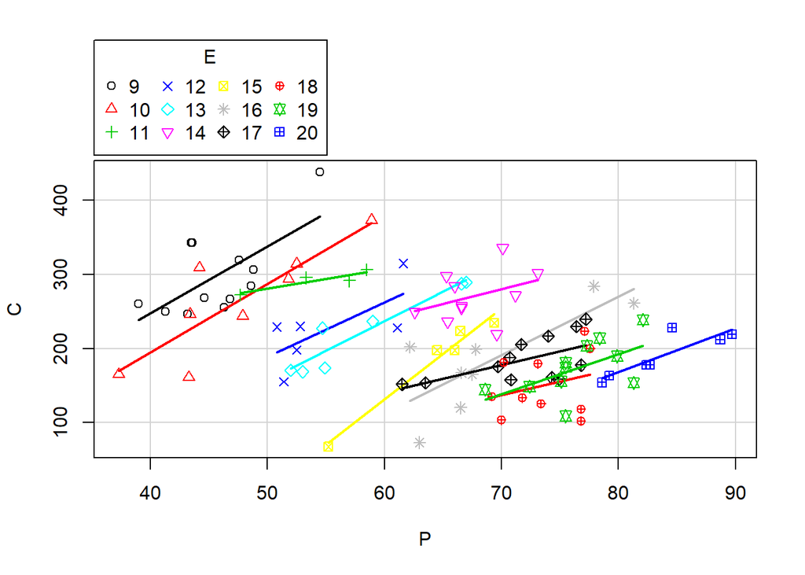

```r
scatterplot(C~P|E,smooth=F,boxplots=F,col=1:12,dd)
```

**b)** Plantegeu ara la regressió múltiple $C_{i}=\beta_{0}+\beta_{1}P_{i}+\beta_{2}H_{i}+\beta_{3}E_{i}+\varepsilon_{i}\;\mathrm{amb}\;\varepsilon_{i}\sim N\left(0,\sigma^{2}\right)$.

**i.** Trobeu els coeficients de la regressió i la variància del error.

**ii.** Dieu si alguna de les variables $\left(P,H,E\right)$ explica el nivell de colesterol. Hi ha col·linealitat?

```r
# b-Models de regressió múltiple

# b-1) Model 3 variables C~P+E+H
summary(mod3v<-lm(C~P+E+H,dd))
```

```
##
## Call:
## lm(formula = C ~ P + E + H, data = dd)
##
## Residuals:
##     Min      1Q  Median      3Q     Max
## -74.608 -22.137   1.888  21.156  65.410
##
## Coefficients:
##             Estimate Std. Error t value Pr(>|t|)
## (Intercept) 490.9978    35.0517  14.008  < 2e-16 ***
## P            10.3773     0.7365  14.090  < 2e-16 ***
## E           -13.0195     3.8530  -3.379  0.00105 **
## H            -5.0989     0.7227  -7.055 2.68e-10 ***
## ---
## Signif. codes:  0 '***' 0.001 '**' 0.01 '*' 0.05 '.' 0.1 ' ' 1
##
## Residual standard error: 30.11 on 96 degrees of freedom
## Multiple R-squared:  0.8101, Adjusted R-squared:  0.8041
## F-statistic: 136.5 on 3 and 96 DF,  p-value: < 2.2e-16
```

```r
anova(mod0,mod3v)
```

```
## Analysis of Variance Table
##
## Model 1: C ~ 1
## Model 2: C ~ P + E + H
##   Res.Df    RSS Df Sum of Sq      F    Pr(>F)
## 1     99 458219
## 2     96  87031  3    371188 136.48 < 2.2e-16 ***
## ---
## Signif. codes:  0 '***' 0.001 '**' 0.01 '*' 0.05 '.' 0.1 ' ' 1
```

```r
Anova(mod3v) # Com summary t^2=F
```

```
## Anova Table (Type II tests)
##
## Response: C
##           Sum Sq Df F value    Pr(>F)
## P         179985  1 198.533 < 2.2e-16 ***
## E          10351  1  11.418  0.001052 **
## H          45123  1  49.773 2.676e-10 ***
## Residuals  87031 96
## ---
## Signif. codes:  0 '***' 0.001 '**' 0.01 '*' 0.05 '.' 0.1 ' ' 1
```

```r
vif(mod3v)
```

```
##         P         E         H
##  9.489406 20.904776 31.695499
```

**iii.** Utilitzant diagnòstics dieu si el model és correcte.

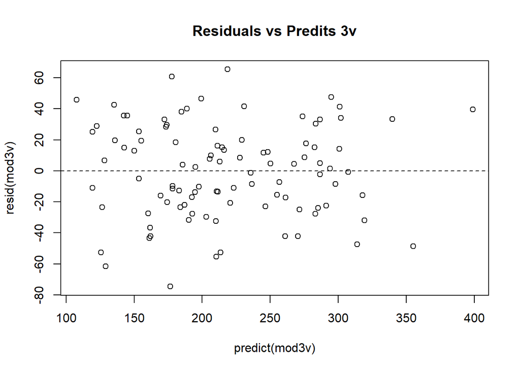

```r
# Diagnòstic: TENDÈNCIES
plot(predict(mod3v),resid(mod3v),main="Residuals vs Predits 3v")
abline(h=0,lty=2)
```

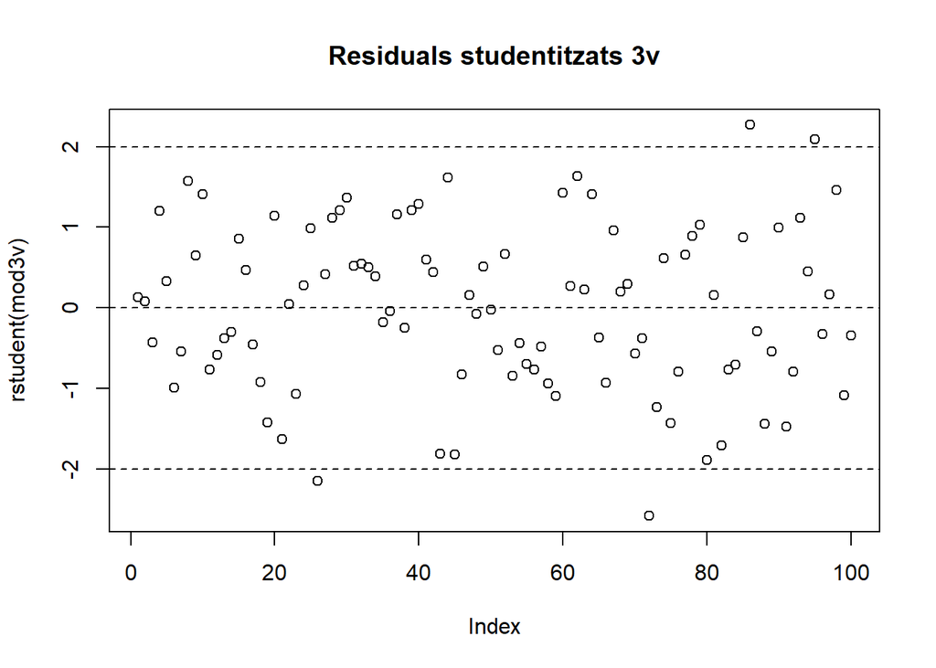

```r
# Diagnòstic: VALORS ESTRANYS
plot(rstudent(mod3v),main="Residuals studentitzats 3v")
abline(h=c(-3,-2,0,2,3),lty=2)
```

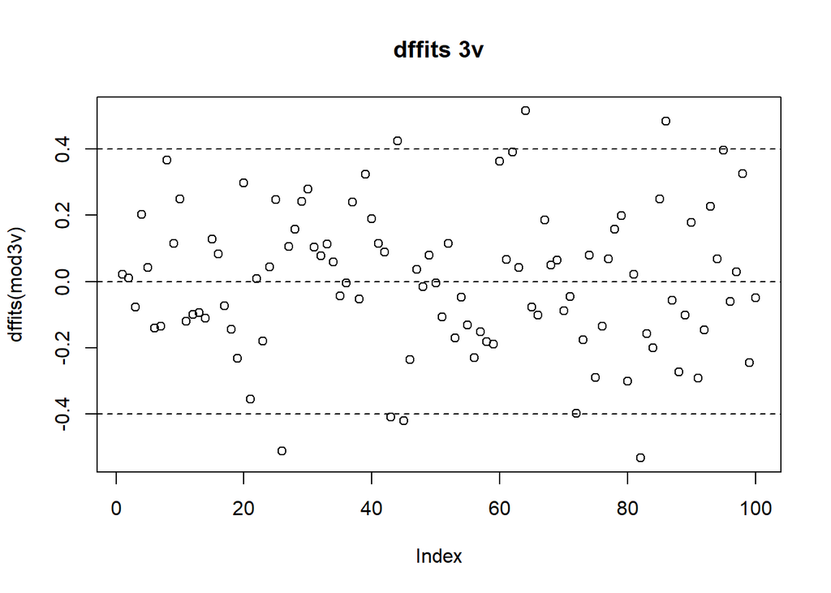

```r
# Diagnòstic: VALORS INFLUENTS
p<-4
plot(dffits(mod3v),main="dffits 3v")
abline(h=c(-3,-2,0,2,3)*sqrt(p/n),lty=2)
```

```r
#=============================================================================
```

**c)** En l’enunciat hi ha una falta de precisió, no és el pes el que fa augmentar el nivell de colesterol si no l’excés de pes. Si per aquest rang d’edats coneixem el patró de pes P=-10+0.5H. Calculeu l’excés de pes $\left(EP\right)$ i plantegeu la regressió múltiple $C_{i}=\beta_{0}+\beta_{1}EP_{i}+\beta_{2}H_{i}+\beta_{3}E_{i}+\varepsilon_{i}\;\mathrm{amb}\;\varepsilon_{i}\sim N\left(0,\sigma^{2}\right)$

**i.** Trobeu els coeficients de la regressió i la variància del error.

```r
# c)-Models amb excés de pes en lloc de pes, ja que tenim un patró del pes.
# pes0=.5*alçada-10

dd$EP<-dd$P-(dd$H/2-10)

# c-1) Model 3 variables C~EP+E+H
summary(modE3v<-lm(C~EP+E+H,dd))
```

```
##
## Call:
## lm(formula = C ~ EP + E + H, data = dd)
##
## Residuals:
##     Min      1Q  Median      3Q     Max
## -74.608 -22.137   1.888  21.156  65.410
##
## Coefficients:
##              Estimate Std. Error t value Pr(>|t|)
## (Intercept) 387.22473   33.69605  11.492  < 2e-16 ***
## EP           10.37731    0.73649  14.090  < 2e-16 ***
## E           -13.01948    3.85300  -3.379  0.00105 **
## H             0.08972    0.58736   0.153  0.87891
## ---
## Signif. codes:  0 '***' 0.001 '**' 0.01 '*' 0.05 '.' 0.1 ' ' 1
##
## Residual standard error: 30.11 on 96 degrees of freedom
## Multiple R-squared:  0.8101, Adjusted R-squared:  0.8041
## F-statistic: 136.5 on 3 and 96 DF,  p-value: < 2.2e-16
```

**ii.** Quines diferències hi ha respecte la regressió de l’apartat b)? Les prediccions són iguals?

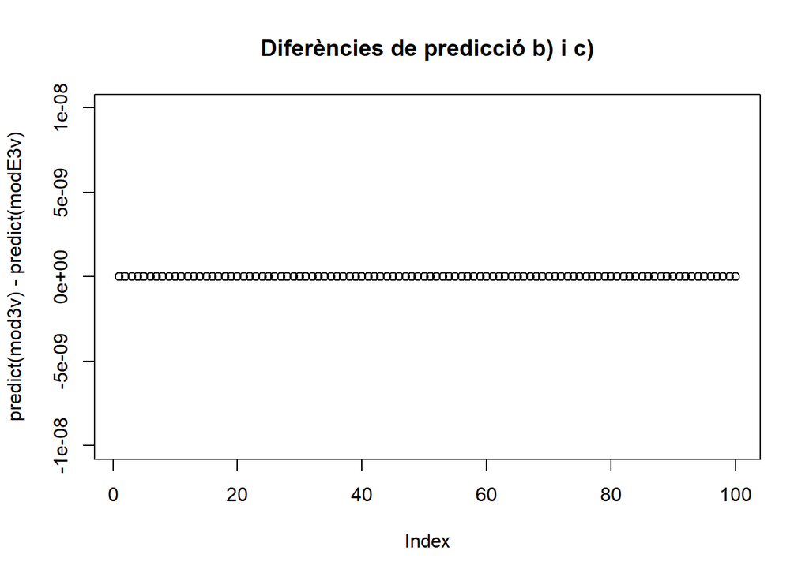

```r
# Diferències amb el model anterior
plot(predict(mod3v)-predict(modE3v),ylim=c(-1e-8,1e-8),main="Diferències de predicció b) i c)")
```

```r
c("S b)"=summary(mod3v)$sigma,"S c)"=summary(modE3v)$sigma)
```

```
##    S b)    S c)
## 30.1094 30.1094
```

```r
rbind("b)"=coef(mod3v),"c)"=coef(modE3v))
```

```
##    (Intercept)        P         E           H
## b)    490.9978 10.37731 -13.01948 -5.09893129
## c)    387.2247 10.37731 -13.01948  0.08972175
```

**iii.** Dieu si alguna de les variables $\left(EP,H,E\right)$ explica el nivell de colesterol. Hi ha col·linealitat?

```r
# Tests i colinealitat
anova(mod0,modE3v) #igual que el de b)
```

```
## Analysis of Variance Table
##
## Model 1: C ~ 1
## Model 2: C ~ EP + E + H
##   Res.Df    RSS Df Sum of Sq      F    Pr(>F)
## 1     99 458219
## 2     96  87031  3    371188 136.48 < 2.2e-16 ***
## ---
## Signif. codes:  0 '***' 0.001 '**' 0.01 '*' 0.05 '.' 0.1 ' ' 1
```

```r
Anova(modE3v) # Com summary t^2=F
```

```
## Anova Table (Type II tests)
##
## Response: C
##           Sum Sq Df  F value    Pr(>F)
## EP        179985  1 198.5328 < 2.2e-16 ***
## E          10351  1  11.4180  0.001052 **
## H             21  1   0.0233  0.878913
## Residuals  87031 96
## ---
## Signif. codes:  0 '***' 0.001 '**' 0.01 '*' 0.05 '.' 0.1 ' ' 1
```

```r
vif(modE3v)
```

```
##        EP         E         H
##  1.009937 20.904776 20.933520
```

**iv.** Utilitzant diagnòstics dieu si el model és correcte.

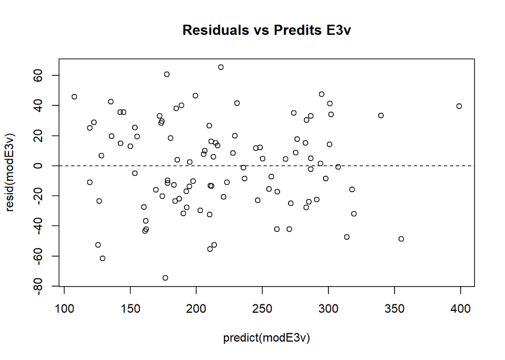

```r
# Diagnòstic: TENDÈNCIES Tots iguals que els de b)
plot(predict(modE3v),resid(modE3v),main="Residuals vs Predits E3v")
abline(h=0,lty=2)
```

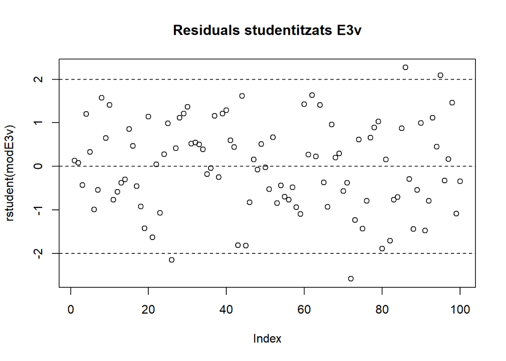

```r
# Diagnòstic: VALORS ESTRANYS
plot(rstudent(modE3v),main="Residuals studentitzats E3v")
abline(h=c(-3,-2,0,2,3),lty=2)
```

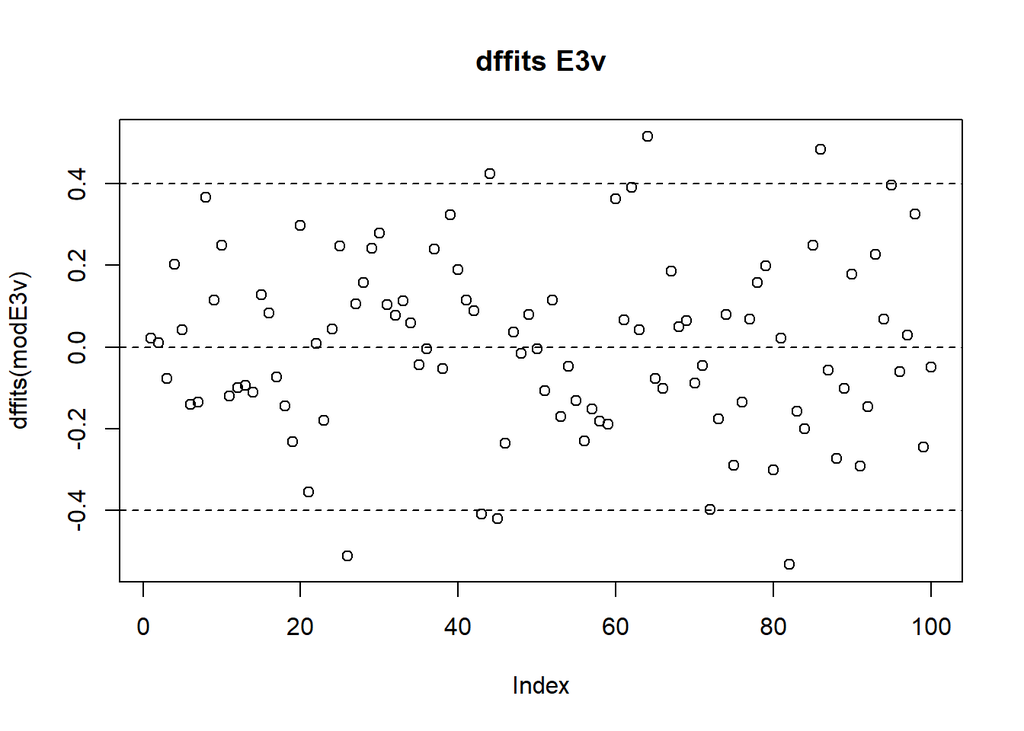

```r
# Diagnòstic: VALORS INFLUENTS
p<-4
plot(dffits(modE3v),main="dffits E3v")
abline(h=c(-3,-2,0,2,3)*sqrt(p/n),lty=2)
```

```r
#=============================================================================
```

**d)** Si es pot, simplifica el model de l’apartat c).

**i.** Trobeu els coeficients de la regressió i la variància del error.

```r
# d-1) Model 2 variables C~EP+E
modE2v<-lm(C~EP+E,dd)
summary(modE2v)
```

```
##
## Call:
## lm(formula = C ~ EP + E, data = dd)
##
## Residuals:
##     Min      1Q  Median      3Q     Max
## -74.286 -22.638   1.755  20.935  66.244
##
## Coefficients:
##             Estimate Std. Error t value Pr(>|t|)
## (Intercept) 391.9885    12.6975   30.87   <2e-16 ***
## EP           10.3882     0.7294   14.24   <2e-16 ***
## E           -12.4452     0.8387  -14.84   <2e-16 ***
## ---
## Signif. codes:  0 '***' 0.001 '**' 0.01 '*' 0.05 '.' 0.1 ' ' 1
##
## Residual standard error: 29.96 on 97 degrees of freedom
## Multiple R-squared:   0.81,  Adjusted R-squared:  0.8061
## F-statistic: 206.8 on 2 and 97 DF,  p-value: < 2.2e-16
```

**ii.** Quines diferències hi ha respecte la regressió de l’apartat c)? Les prediccions són iguals?

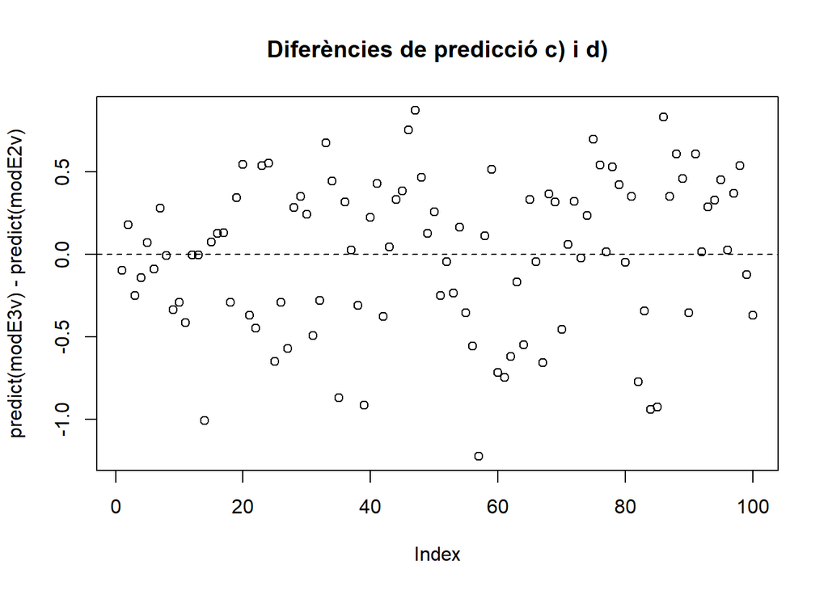

```r
# Diferències amb el model anterior
plot(predict(modE3v)-predict(modE2v),main="Diferències de predicció c) i d)")
abline(h=0,lt=2)
```

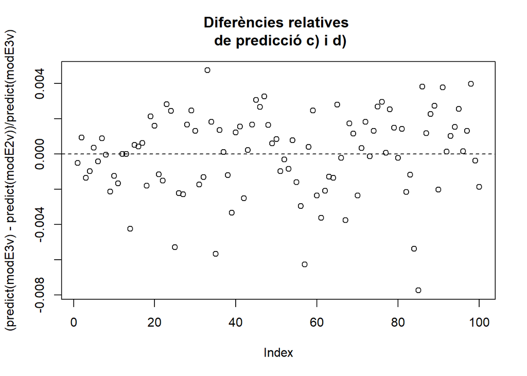

```r
plot((predict(modE3v)-predict(modE2v))/predict(modE3v),main="Diferències relatives \n de predicció c) i d)")
abline(h=0,lt=2)
```

```r
c("S c)"=summary(modE3v)$sigma,"S d)"=summary(modE2v)$sigma) # d) variància més petita
```

```
##     S c)     S d)
## 30.10940 29.95743
```

```r
rbind("c)"=coef(modE3v),"d)"=c(coef(modE2v),0))
```

```
##    (Intercept)       EP         E          H
## c)    387.2247 10.37731 -13.01948 0.08972175
## d)    391.9885 10.38817 -12.44518 0.00000000
```

```r
anova(modE2v,modE3v)
```

```
## Analysis of Variance Table
##
## Model 1: C ~ EP + E
## Model 2: C ~ EP + E + H
##   Res.Df   RSS Df Sum of Sq      F Pr(>F)
## 1     97 87052
## 2     96 87031  1    21.154 0.0233 0.8789
```

**iii.** Dieu si alguna de les variables $\left(EP,E\right)$ explica el nivell de colesterol. Hi ha col·linealitat?

```r
# Tests i colinealitat
anova(mod0,modE2v) #igual que el de b)
```

```
## Analysis of Variance Table
##
## Model 1: C ~ 1
## Model 2: C ~ EP + E
##   Res.Df    RSS Df Sum of Sq      F    Pr(>F)
## 1     99 458219
## 2     97  87052  2    371167 206.79 < 2.2e-16 ***
## ---
## Signif. codes:  0 '***' 0.001 '**' 0.01 '*' 0.05 '.' 0.1 ' ' 1
```

```r
Anova(modE2v) # Com summary t^2=F
```

```
## Anova Table (Type II tests)
##
## Response: C
##           Sum Sq Df F value    Pr(>F)
## EP        182058  1  202.86 < 2.2e-16 ***
## E         197617  1  220.20 < 2.2e-16 ***
## Residuals  87052 97
## ---
## Signif. codes:  0 '***' 0.001 '**' 0.01 '*' 0.05 '.' 0.1 ' ' 1
```

```r
vif(modE2v)
```

```
##       EP        E
## 1.000527 1.000527
```

**iv.** Utilitzant diagnòstics dieu si el model és correcte.

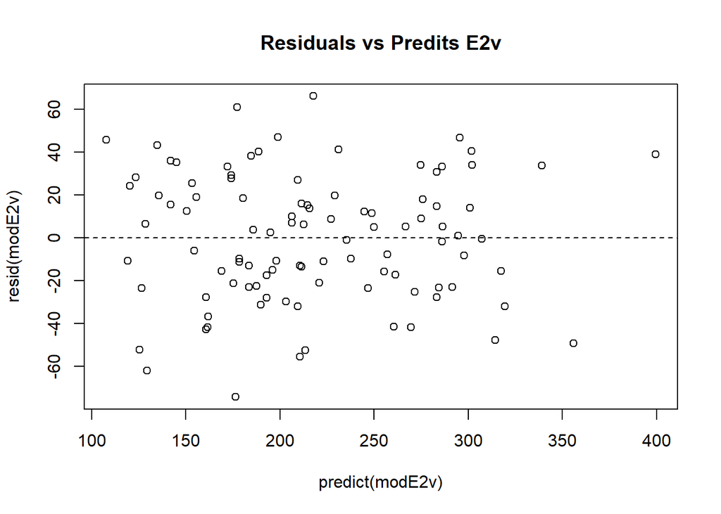

```r
plot(predict(modE2v),resid(modE2v),main="Residuals vs Predits E2v")
abline(h=0,lty=2)
```

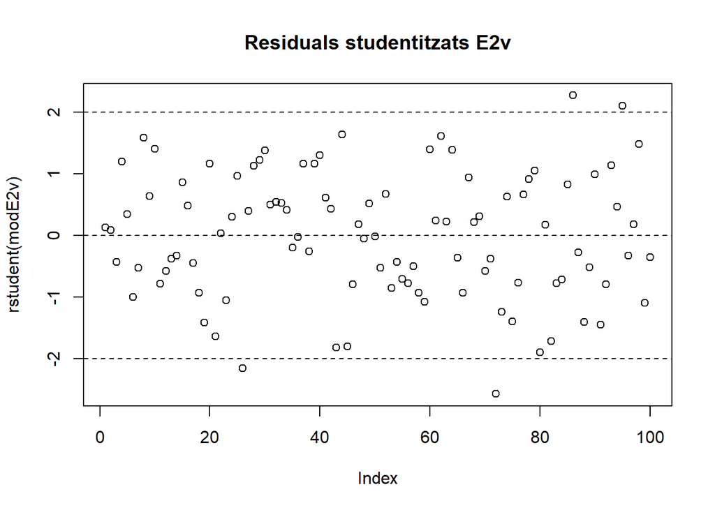

```r
# Diagnòstic: VALORS ESTRANYS
plot(rstudent(modE2v),main="Residuals studentitzats E2v")
abline(h=c(-3,-2,0,2,3),lty=2)
```

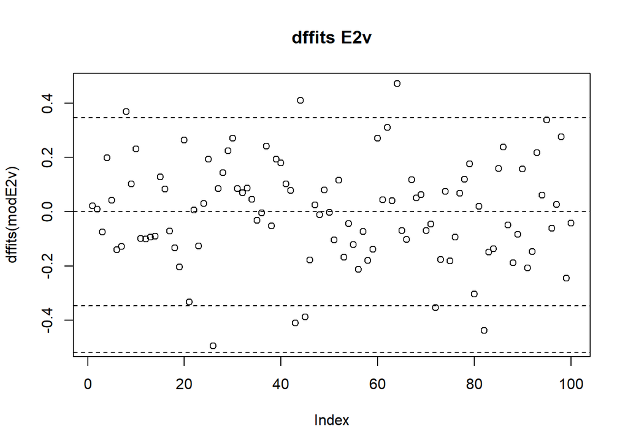

```r
# Diagnòstic: VALORS INFLUENTS
p<-3
plot(dffits(modE2v),main="dffits E2v")
abline(h=c(-3,-2,0,2,3)*sqrt(p/n),lty=2)
```

```r
#=============================================================================
```

**e)** Amb el model més simplificat

**i.** Pels que no tenen excés de pes, dibuixeu la banda de predicció del colesterol $_{95\%}$ respecte l’edat.

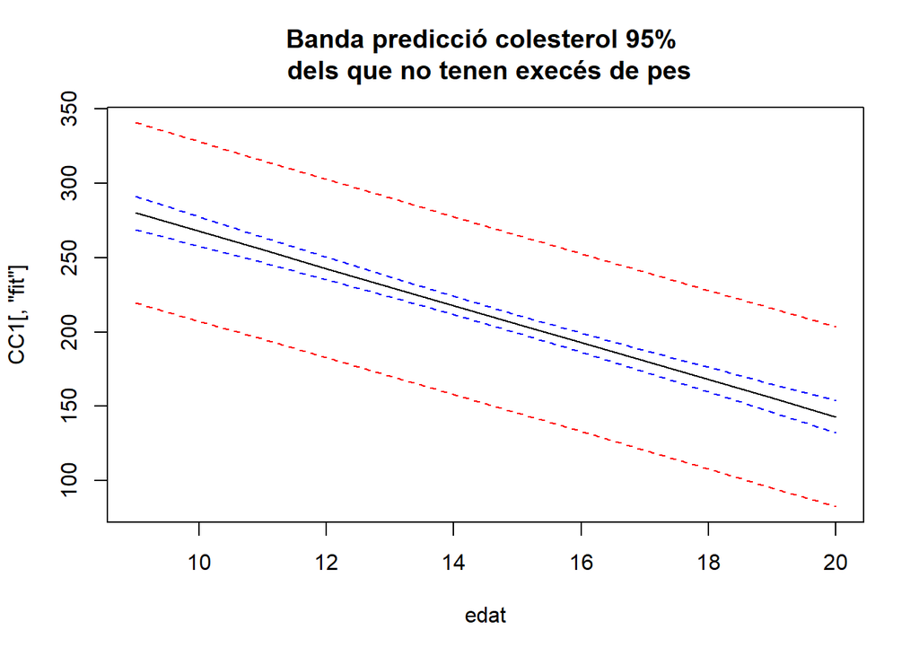

```r
# e) Prediccions amb el model modE2v

edat<-9:20
C1<-data.frame(cbind(E=edat,EP=0))
CC1<-predict(modE2v,C1,interval="confidence")
CP1<-predict(modE2v,C1,interval="prediction")

plot(edat,CC1[,"fit"],ty="l",ylim=c(min(CP1),max(CP1)),main="Banda predicció colesterol 95% \n dels que no tenen execés de pes")
lines(edat,CC1[,"lwr"],lty=2,col="blue")
lines(edat,CC1[,"upr"],lty=2,col="blue")
lines(edat,CP1[,"lwr"],lty=2,col="red")
lines(edat,CP1[,"upr"],lty=2,col="red")
```

**ii.** Per 3 persones amb P={60, 65 70}, però E=15 i H=150, utilitzant el millor dels models anteriors, calculeu-ne:

• Les e regions de “predicció del 95%” del colesterol.

```r
#Per alguns casos predeterminats, IC de E(Y)
C0<-data.frame(cbind(EP=c(c(60,65,70)-(150/2-10)),E=c(15)))
predict(modE2v, C0, interval="prediction", level=.95)
```

```
##        fit       lwr      upr
## 1 153.3700  93.00771 213.7323
## 2 205.3108 145.54102 265.0806
## 3 257.2516 197.20145 317.3018
```

• Els 3 intervals de confiança $IC_{95\%}\left(E\left[C|P=60,E=15,H=150\right]\right)$, $IC_{95\%}\left(E\left[C|P=65,E=15,H=150\right]\right)$ i $IC_{95\%}\left(E\left[C|P=70,E=15,H=150\right]\right)$.

```r
#Per alguns casos predeterminats, IC de E(Y)
predict(modE2v, C0, interval="confidence", level=.95)
```

```
##        fit      lwr      upr
## 1 153.3700 142.9563 163.7836
## 2 205.3108 199.2060 211.4157
## 3 257.2516 248.8334 265.6699
```

• Amb un nivell de significació del 5%, contrasteu els 3 test:

$H_{0}:E\left[C|P=60,E=15,H=150\right]=200$ vs $H_{1}:E\left[C|P=60,E=15,H=150\right]\neq200$.

$H_{0}:E\left[C|P=65,E=15,H=150\right]=200$ vs $H_{1}:E\left[C|P=65,E=15,H=150\right]\neq200$.

$H_{0}:E\left[C|P=70,E=15,H=150\right]=200$ vs $H_{1}:E\left[C|P=70,E=15,H=150\right]\neq200$.

```r
lht(modE2v,c(1,-5,15),200)
```

```
## Linear hypothesis test
##
## Hypothesis:
## (Intercept) - 5 EP  + 15 E = 200
##
## Model 1: restricted model
## Model 2: C ~ EP + E
##
##   Res.Df    RSS Df Sum of Sq      F    Pr(>F)
## 1     98 157934
## 2     97  87052  1     70882 78.981 3.384e-14 ***
## ---
## Signif. codes:  0 '***' 0.001 '**' 0.01 '*' 0.05 '.' 0.1 ' ' 1
```

```r
lht(modE2v,c(1,0,15),200)
```

```
## Linear hypothesis test
##
## Hypothesis:
## (Intercept)  + 15 E = 200
##
## Model 1: restricted model
## Model 2: C ~ EP + E
##
##   Res.Df   RSS Df Sum of Sq      F  Pr(>F)
## 1     98 89728
## 2     97 87052  1    2675.4 2.9811 0.08743 .
## ---
## Signif. codes:  0 '***' 0.001 '**' 0.01 '*' 0.05 '.' 0.1 ' ' 1
```

```r
lht(modE2v,c(1,5,15),200)
```

```
## Linear hypothesis test
##
## Hypothesis:
## (Intercept)  + 5 EP  + 15 E = 200
##
## Model 1: restricted model
## Model 2: C ~ EP + E
##
##   Res.Df    RSS Df Sum of Sq      F    Pr(>F)
## 1     98 250562
## 2     97  87052  1    163510 182.19 < 2.2e-16 ***
## ---
## Signif. codes:  0 '***' 0.001 '**' 0.01 '*' 0.05 '.' 0.1 ' ' 1
```

```r
# o bé manualment
print(pC<-predict(modE2v,C0,se.fit=T))
```

```
## $fit
##        1        2        3
## 153.3700 205.3108 257.2516
##
## $se.fit
##        1        2        3
## 5.246904 3.075920 4.241510
##
## $df
## [1] 97
##
## $residual.scale
## [1] 29.95743
```

```r
print(((pC$fit-200)/pC$se.fit)^2)
```

```
##          1          2          3
##  78.981395   2.981075 182.194390
```

```r
print(2*(1-pt(abs(pC$fit-200)/pC$se.fit,pC$df)))
```

```
##            1            2            3
## 3.375078e-14 8.742681e-02 0.000000e+00
```